# VARshrink: An R Package for Shrinkage Estimation of High-Dimensional Vector Autoregressive Models

Vector autoregressive (VAR) models are widely used to study dynamic relationships in multivariate time series, with applications ranging from economic and financial forecasting to gene network analysis in systems biology and brain connectivity analysis in neuroscience. High-dimensional VAR models involve many parameters, increasing computational costs and making coefficient estimation more challenging. Shrinkage methods address these challenges by regularizing the coefficient estimates and improving their stability. We present the R package VARshrink, which provides ridge, nonparametric, fully Bayesian, and semiparametric shrinkage estimators through a unified interface. As its main design feature, VARshrink returns objects that inherit from classes in the widely used vars package, allowing existing methods for analysis, visualization, and forecasting to be reused. The package also supports model comparison using information criteria adapted to shrinkage estimation. We illustrate the main workflow with reproducible R code and compare the implemented estimators in numerical experiments.

Namgil Lee (Kangwon National University) , Sung-Ho Kim (KAIST)  
2026-08-08

## 1 Introduction

Vector autoregressive (VAR) models describe the joint dynamics of multiple time series through their lagged values. They are widely used for macroeconomic forecasting and policy analysis, financial modeling, the inference of gene regulatory networks from time-course data in systems biology, and the analysis of dynamic brain connectivity in neuroscience (Hamilton 1994; Harrison et al. 2003; Opgen-Rhein and Strimmer 2007; Koop and Korobilis 2010). However, the number of parameters increases rapidly with both the number of variables and the lag order. High-dimensional VAR models can therefore be computationally demanding and difficult to estimate reliably. Shrinkage methods address these challenges by regularizing coefficient estimates, thereby improving estimation stability and potentially forecasting performance.

Several **R** packages provide methods for VAR and related multivariate time-series models. The MTS package provides tools for VAR, VARMA, seasonal VARMA, and other multivariate time-series models (Tsay and Wood 2018), while vars supports estimation, inference, forecasting, and diagnostic analysis for VAR, SVAR, and SVEC models (Pfaff and Stigler 2018). For large systems, BigVAR estimates VAR and VARX models using structured penalties (Nicholson et al. 2026), whereas bigtime estimates sparse VAR, VARX, and VARMA models using structured lasso penalties (Wilms et al. 2023).

Several packages also support Bayesian VAR analysis. bvartools assists in setting up Bayesian inference for VAR and vector error-correction models (Mohr 2024). bayesianVARs implements MCMC estimation of Bayesian VARs with shrinkage priors and stochastic volatility (Gruber et al. 2026), while bvarsv implements time-varying parameter VARs with stochastic volatility (Primiceri 2005; Krueger 2015). BVAR implements hierarchical prior selection for conjugate priors following Giannone et al. (2015; Kuschnig and Vashold 2021). bsvarSIGNs uses Minnesota and dummy-observation priors with estimated hyperparameters in structural VARs identified by sign, zero, and narrative restrictions (Wang and Woźniak 2025).

In this study, we focus on shrinkage estimation of VAR model parameters. Shrinkage estimation methods have played crucial roles in high-dimensional statistical modeling (Ledoit and Wolf 2004; Böhm and von Sachs 2009; Fiecas and Ombao 2011; Beltrachini et al. 2013). For VAR models, an extensive literature has developed on regularization and shrinkage priors, including Minnesota-type priors and more recent global-local shrinkage priors. Frequentist penalized estimation has also been widely studied. Approaches directly related to this package include a Stein-type nonparametric shrinkage estimation method (Opgen-Rhein and Strimmer 2007), Bayesian VARs using informative priors (Doan et al. 1984; Litterman 1986; Bańbura et al. 2010; Koop and Korobilis 2010), Bayesian VARs using noninformative priors (Sun and Ni 2004; Ni and Sun 2005), and a semiparametric Bayesian approach adopting a modified $K$-fold cross-validation (Lee et al. 2016).

Shrinkage methods developed for purposes other than multivariate time series analysis can also be applied to the estimation of VAR parameters. For instance, the function `cov.shrink()` in the package corpcor was developed to compute shrinkage estimates of covariances, but it has also been used to estimate VAR coefficients (Opgen-Rhein and Strimmer 2007; Schäfer et al. 2017). Moreover, VAR models can be reformulated as multivariate regression problems, allowing penalized least squares methods to be used for shrinkage estimation of VAR parameters. Examples include the functions `lm.gls()` for generalized least squares and `lm.ridge()` for ridge regression in the package MASS (Ripley et al. 2018); the function `glmnet()` for Lasso and Elastic-Net regularized generalized linear models in the package glmnet (Friedman et al. 2018); the function `linearRidge()` for ridge regression in the package ridge (Moritz and Cule 2018).

While Bayesian approaches have been widely used in the literature, nonparametric and semiparametric approaches have advantages for high-dimensional VARs with several hundred or more time series variables due to their relatively low computational cost (Opgen-Rhein and Strimmer 2007). In contrast, Bayesian approaches can flexibly impose proper assumptions on multivariate time series data, such as VAR roots near unity and correlations among noise processes (Lee et al. 2016). In this sense, a semiparametric approach serves as a trade-off between nonparametric and parametric approaches (Lee et al. 2016).

The main design contribution of VARshrink is to extend the workflow of vars from ordinary least squares to shrinkage estimation. Users can apply familiar methods from vars, including ARCH-LM tests, causality analysis, diagnostic plots, forecasting, impulse response analysis, and forecast error variance decomposition, directly to **R** objects obtained via shrinkage estimation methods in VARshrink. This compatibility also allows shrinkage methods to be introduced within established applied and teaching workflows based on vars.

Relative to existing implementations, VARshrink brings together ridge regression, a Stein-type nonparametric estimator, fully Bayesian estimation, and semiparametric Bayesian estimation in one interface. Its fully Bayesian method includes both a natural conjugate normal-Wishart prior and a non-conjugate shrinkage-reference prior, with scale-mixture likelihoods available for robust estimation. The package also provides likelihood and information criterion methods that account for the selected noise distribution and the effective number of parameters. These features are intended to complement packages specializing in structured penalties, hierarchical Bayesian prior selection, stochastic volatility, or structural identification.

This paper is organized as follows. In Section 2, we formulate VAR models as a multivariate regression problem, which simplifies the implementation of the package. We also describe the general distributional assumptions for the noise term within a Bayesian framework. Closed-form expressions for the shrinkage estimators implemented in the package are presented to clarify the role of the shrinkage intensity parameters in each method. In addition, we explain how the effective number of parameters is computed for shrinkage estimators. Section 3 introduces the common interface function and provides sample code snippets to demonstrate the usefulness of the package. In Section 4, we present numerical experiments using benchmark and simulated data to compare the performance of the shrinkage estimation methods. Discussion and conclusions are given in Sections 5 and 6.

## 2 Models

### 2.1 Multivariate linear regression formulation

Let $\mathbf{y}_t = (y_{t1},y_{t2},\ldots,y_{tK})^\top$ denote a $K\times 1$ vector of endogenous variables. A VAR model of order $p$ can be expressed as
$$\begin{equation}
\mathbf{y}_t = \mathbf{A}_1 \mathbf{y}_{t-1} + \cdots + \mathbf{A}_p \mathbf{y}_{t-p} + \mathbf{C} \mathbf{d}_t + \boldsymbol\epsilon_t,
\tag{1}
\end{equation}$$
where $\mathbf{d}_t$ is an $L\times 1$ vector of deterministic regressors, $\boldsymbol\epsilon_t$ is a $K\times 1$ noise vector, and $\mathbf{A}_1,\ldots,\mathbf{A}_p$ and $\mathbf{C}$ are coefficient matrices (Hamilton 1994; Tsay 2005).

The model equation (1) can be expressed in the matrix form of a multivariate regression as
$$\begin{equation}
\mathbf{Y} = \mathbf{X} \boldsymbol\Psi + \mathbf{E} \in \mathbb{R}^{N \times K},
\tag{2}
\end{equation}$$
where $\boldsymbol\Psi = (\mathbf{A}_1, \mathbf{A}_2, \ldots, \mathbf{A}_p, \mathbf{C})^\top$ is a $(Kp + L) \times K$ matrix of coefficients,
$$\begin{equation}
\begin{split}
\mathbf{Y} &= ( \mathbf{y}_{p+1}, \mathbf{y}_{p+2}, \ldots, \mathbf{y}_{T} )^\top \in \mathbb{R}^{N \times K},
\\
\mathbf{X} &= ( \mathbf{x}_{p+1}, \mathbf{x}_{p+2}, \ldots, \mathbf{x}_{T} )^\top \in \mathbb{R}^{N \times (Kp + L)}
\end{split}
\end{equation}$$
are data matrices with $\mathbf{x}_t = (\mathbf{y}_{t-1}^\top, \ldots, \mathbf{y}_{t-p}^\top, \mathbf{d}_t^\top)^\top \in \mathbb{R}^{Kp + L}$, $\mathbf{E} = (\boldsymbol\epsilon_{p+1}, \ldots, \boldsymbol\epsilon_T)^\top$, and $N = T-p$.

### 2.2 Mathematical expressions for shrinkage estimators

In version 0.5 of the **R** package VARshrink, ordinary least squares (OLS) and five shrinkage estimation methods are implemented: multivariate ridge regression (Hoerl and Kennard 1970; Golub et al. 1979; Ripley et al. 2018), a Stein-type nonparametric shrinkage method (Schäfer and Strimmer 2005; Opgen-Rhein and Strimmer 2007; Schäfer et al. 2017), a full Bayesian shrinkage method (Sun and Ni 2004; Ni and Sun 2005), and two semiparametric Bayesian shrinkage methods based on parameterized and K-fold cross-validation, respectively (Lee et al. 2016). OLS is included as a baseline for settings in which the VAR is estimable without shrinkage. For each shrinkage estimation method, the shrinkage estimator of the coefficient matrix $\boldsymbol\Psi$ takes a distinct mathematical form.

#### (1) Multivariate ridge regression

The ridge regression estimator, $\widehat{ \boldsymbol\Psi }^\text{R} (\lambda)$, can be expressed in a closed form as follows (Hoerl and Kennard 1970):
$$\begin{equation}
\widehat{ \boldsymbol\Psi }^\text{R} (\lambda) =
\left( \mathbf{X}^\top \mathbf{X} + N \lambda \mathbf{I} \right)^{-1} \mathbf{X}^\top \mathbf{Y},
\end{equation}$$
where $\lambda \geq 0$ is called the regularization parameter or the shrinkage parameter.

#### (2) Stein-type nonparametric shrinkage method

Suppose that the VAR model does not include a constant term, that is, a regressor whose value remains constant over time (e.g., $d_t = 1$). Assuming that the data matrices $\mathbf{X}$ and $\mathbf{Y}$ have been mean-corrected, let $\mathbf{S}_\text{XX} = (N - 1)^{-1} \mathbf{X}^\top \mathbf{X}$, $\mathbf{S}_\text{XY} = (N - 1)^{-1} \mathbf{X}^\top \mathbf{Y}$, and $\mathbf{S}_\text{YY} = (N - 1)^{-1} \mathbf{Y}^\top \mathbf{Y}$ denote the sample covariance matrices, $\mathbf{D}_\text{X} = \text{diag}(\mathbf{S}_\text{XX})$ and $\mathbf{D}_\text{Y} = \text{diag}(\mathbf{S}_\text{YY})$ denote the diagonal matrices of sample variances, and $\mathbf{R}_\text{XX}$, $\mathbf{R}_\text{XY}$, and $\mathbf{R}_\text{YY}$ denote the sample correlation matrices. The shrinkage estimators of the correlation matrices are defined as:
$$\begin{equation}
\widehat{\mathbf{R}}_\text{XX} =
(1-\lambda) \mathbf{R}_\text{XX} + \lambda \mathbf{I}
,
\qquad
\widehat{\mathbf{R}}_\text{XY} =
(1-\lambda) \mathbf{R}_\text{XY},
\end{equation}$$
where $0 \leq \lambda \leq 1$ is the shrinkage parameter for the correlations. And the shrinkage estimators of the variance matrices are defined as:
$$\begin{equation}
\widehat{\mathbf{D}}_\text{X} =
(1-\lambda_v) \mathbf{D}_\text{X} +
\lambda_v s_\text{med} \mathbf{I},
\ \ \widehat{\mathbf{D}}_\text{Y} =
(1-\lambda_v) \mathbf{D}_{\text{Y}} +
\lambda_v s_\text{med} \mathbf{I},
\end{equation}$$
where $0 \leq \lambda_v \leq 1$ is the shrinkage parameter for the variances, and $s_\text{med}$ is the median of all sample variances.

The nonparametric shrinkage (NS) estimator of $\boldsymbol\Psi$ can be expressed as follows (Schäfer and Strimmer 2005; Opgen-Rhein and Strimmer 2007):
$$\begin{equation}
\widehat{ \boldsymbol\Psi }^\text{N} (\lambda, \lambda_v) =
\widehat{\mathbf{D}}_\text{X}^{-1/2}
\widehat{\mathbf{R}}_\text{XX}^{-1}
\widehat{\mathbf{R}}_\text{XY}
\widehat{\mathbf{D}}_\text{Y}^{1/2}.
\end{equation}$$
The shrinkage estimate $\widehat{ \boldsymbol\Psi }^\text{N} (\lambda, \lambda_v)$ approaches the ordinary least squares estimate, $\widehat{\boldsymbol\Psi}^{\text{OLS}} = \mathbf{S}_\text{XX}^{-1} \mathbf{S}_\text{XY}$, as $\lambda$ and $\lambda_v$ approach zero.

#### (3) Full Bayesian shrinkage method

The full Bayesian shrinkage method supports several likelihood and prior specifications.

##### Likelihoods

We assume that the noise vectors are independent and identically distributed from a scale mixture of multivariate normal distributions, including multivariate normal distributions, multivariate t-distributions (Ni and Sun 2005), and multivariate Laplace distributions (MLD) (Eltoft et al. 2006). By incorporating scale mixture distributions in the model assumption, we can handle outliers appropriately and produce robust estimates (West 1984). In specific, we consider that a noise vector can be expressed as a product
$$\begin{equation}
\boldsymbol\epsilon_t = \mathbf{z}_t q_t^{-1/2},
\tag{3}
\end{equation}$$
where $\mathbf{z}_t \sim \text{N}_K(\mathbf{0}, \mathbf{\Sigma})$ is a $K\times 1$ vector having a multivariate normal distribution with the mean vector of zeros and the covariance matrix of $\boldsymbol\Sigma$, and $q_t \sim \text{Gamma}(\nu/2, \nu/2)$ is a random variable having a gamma distribution with shape $\alpha = \nu/2$ and rate $\beta = \nu/2$. The $\boldsymbol\epsilon$ has a multivariate t-distribution with degrees of freedom $\nu$ when $1<\nu<\infty$, a multivariate normal distribution as $\nu \rightarrow \infty$, and a multivariate Cauchy distribution when $\nu = 1$. More detailed discussions can be found in the package vignette and Lee et al. (2016).

##### Conjugate prior

Let $\boldsymbol\psi = \text{vec}(\boldsymbol\Psi) \in\mathbb{R}^{J}$ denote the vectorized form of $\boldsymbol\Psi \in\mathbb{R}^{(Kp + L)\times K}$, where $J = K (Kp + L)$. The natural conjugate prior implemented in VARshrink is a normal-Wishart prior. Conditional on $\mathbf{\Sigma}$, the prior for $\boldsymbol\psi$ is
$$\begin{equation}
( \boldsymbol\psi | \mathbf{\Sigma}, \delta )
\sim \text{N}_{J} \left( \mathbf{0}, \delta \mathbf{\Sigma} \otimes \mathbf{I} \right),
\end{equation}$$
where $\otimes$ represents the Kronecker product of two matrices and $\delta \equiv 1 / \lambda > 0$ is a reciprocal of a shrinkage parameter $\lambda > 0$, and an inverse Wishart distribution with a positive definite scale matrix $\mathbf{L}_0$ and degrees of freedom $m_0 > K - 1$ for $\mathbf{\Sigma}$ as
$$\begin{equation}
( \mathbf{\Sigma} | \mathbf{L}_0, m_0 )
\sim \text{InvWishart}\left(\mathbf{L}_0, m_0\right).
\end{equation}$$
The prior distributions for $\delta$ and $w = \nu / 2$ are given by
$$\begin{equation}
\begin{split}
\pi(\delta) & \propto 1, \\
w & \sim \text{Gamma}(a_0, b_0),
\end{split}
\end{equation}$$
for some $a_0, b_0 > 0$.

VARshrink uses a Gibbs MCMC method to sample $(\boldsymbol\psi, \mathbf{Q}, \mathbf{\Sigma}, w, \delta)$ from the conditional posterior distributions; see the package vignette for more details. Let $\mathbf{Q} = \text{diag}(q_{p+1}, \ldots, q_T)$. With $\lambda \equiv 1 / \delta$, the mean of the conditional posterior distribution of $\boldsymbol\psi$ given $(\mathbf{Q}, \mathbf{\Sigma}, w, \delta ; \mathbf{Y} )$ can be written as
$$\begin{equation}
\widehat{\mathbf\Psi}^\text{F}_\text{CJ}( \lambda )
= \left( \mathbf{X}^\top \mathbf{Q} \mathbf{X} + \lambda \mathbf{I} \right)^{-1} \mathbf{X}^\top \mathbf{Q} \mathbf{Y}.
\tag{4}
\end{equation}$$

##### Non-conjugate priors

The non-conjugate prior adopted in **VARshrink** is the shrinkage-reference prior of Ni and Sun (2005), which is given by
$$\begin{equation}
\begin{split}
( \boldsymbol\psi | \delta )
& \sim \text{N}_{J} \left( \mathbf{0}, \delta \mathbf{I} \right),
\\
\pi( \mathbf{\Sigma} )
& \propto |\mathbf{\Sigma}|^{-1} \prod_{1\leq i < j\leq K} (\lambda_i - \lambda_j)^{-1},
\\
\pi(\delta) & \propto 1, \\
w & \sim \text{Gamma}(a_0, b_0),
\end{split}
\end{equation}$$
where $\lambda_1 > \lambda_2 > \cdots > \lambda_K$ are eigenvalues of $\mathbf{\Sigma}$, $w = \nu / 2$, and $a_0, b_0 > 0$.

With $\lambda \equiv 1 / \delta$, the mean of the conditional posterior distribution of $\boldsymbol\psi$ given $(\mathbf{Q}, \mathbf{\Sigma}, w, \delta; \mathbf{Y})$ is given by
$$\begin{equation}
\widehat{\boldsymbol\psi}^\text{F}_\text{NCJ}(\lambda) = \left(\mathbf{\Sigma}^{-1} \otimes \left( \mathbf{X}^\top \mathbf{Q} \mathbf{X} \right) + \lambda \mathbf{I}_J \right)^{-1} \text{vec}\left( \mathbf{X}^\top \mathbf{Q} \mathbf{Y} \mathbf{\Sigma}^{-1} \right).
\tag{5}
\end{equation}$$

#### (4) Semi-parametric shrinkage method

In contrast to the full Bayesian approach, the semiparametric Bayesian approach selects the shrinkage parameter $0 \leq \lambda < 1$ through parameterized cross-validation (Lee et al. 2016). Once the $\lambda$ is fixed, the parameters $\boldsymbol\psi$, $\mathbf{\Sigma}$, and $\mathbf{Q}$ are estimated at the mode of the marginal posterior density $\pi (\boldsymbol\psi, \mathbf{\Sigma} | \lambda; \mathbf{Y})$. In the case of a non-conjugate prior for $\boldsymbol\psi$ (Lee et al. 2016), the mode $\widehat{\boldsymbol\psi}^\text{S} (\lambda)$ is given by
$$\begin{equation}
\widehat{\boldsymbol\psi}^{\text{S}} (\lambda) =
\left[\left( \mathbf{\Sigma}^{-1} \otimes
\left( \mathbf{X}^\top \mathbf{Q} \mathbf{X} \right) \right) + \frac{ (N - 1) \lambda}{1-\lambda} \mathbf{I}_J \right]^{-1}
\text{vec}\left( \mathbf{X}^\top \mathbf{Q} \mathbf{Y} \mathbf{\Sigma}^{-1} \right)
.
\tag{6}
\end{equation}$$
The covariance matrix $\mathbf{\Sigma}$ is estimated in the same manner.

### 2.3 Estimation of the effective number of parameters

Although all shrinkage estimators are expressed in slightly different forms, they approach the ordinary least squares estimator (or the maximum likelihood estimator) as the shrinkage parameters decrease to zero, and they are shrunk toward zeros as the shrinkage parameters increase. It implies that the effective number of parameters underlying a shrinkage estimator is controlled by the shrinkage parameter values.

The shrinkage estimators presented in the previous section can be expressed in a general form:
$$\begin{equation}
\widehat{\boldsymbol\psi} (\lambda_0) = \left[\left(\mathbf{\Sigma}^{-1} \otimes \left( \mathbf{X}^\top \mathbf{Q} \mathbf{X} \right) \right) + \lambda_0 \mathbf{I}_J \right]^{-1} \text{vec}\left( \mathbf{X}^\top \mathbf{Q} \mathbf{Y} \mathbf{\Sigma}^{-1} \right),
\tag{7}
\end{equation}$$
where $\lambda_0 > 0$ is the shrinkage parameter. A noise covariance matrix is approximated by its diagonal elements as $\mathbf{\Sigma} \approx \mathbf{D}_\text{e} \equiv \text{diag}(\mathbf{\Sigma}) = \text{diag}(\sigma_{11}, \ldots, \sigma_{KK})$ to simplify the expression for $\widehat{\boldsymbol\psi} (\lambda_0)$ as:
$$\widehat{\boldsymbol\psi} (\lambda_0)
\approx
\left[\left(\mathbf{I}_K \otimes \left( \mathbf{X}^\top \mathbf{Q} \mathbf{X} \right) \right) + \lambda_0 \mathbf{D}_\text{e} \otimes \mathbf{I}_{J/K} \right]^{-1} \text{vec}\left(\mathbf{X}^\top \mathbf{Q} \mathbf{Y} \right),$$
or equivalently, for each $j=1,2,\ldots,K$,
$$\begin{equation}
\widehat{\boldsymbol\psi}_j (\lambda_0)
\approx
\left( \mathbf{X}^\top \mathbf{Q} \mathbf{X} + \lambda_0 \sigma_{jj} \mathbf{I}_{J/K} \right)^{-1}
\mathbf{X}^\top \mathbf{Q} \mathbf{y}_j
,
\tag{8}
\end{equation}$$
where $\widehat{\boldsymbol\psi}_j (\lambda_0)$ and $\mathbf{y}_j$ are the $j$th column vectors of $\widehat{\boldsymbol\Psi} (\lambda_0)$ and $\mathbf{Y}$.

From the definition of a hat matrix, $\mathbf{H}(j, \lambda_0)$, we have $\widehat{\mathbf{y}}_j \equiv \mathbf{H}(j, \lambda_0) \mathbf{y}_j = \mathbf{X} \widehat{\boldsymbol\psi}_j(\lambda_0)$, and the hat matrix can be expressed as: $\mathbf{H}(j, \lambda_0) \equiv \mathbf{X} \left( \mathbf{X}^\top \mathbf{Q} \mathbf{X} + \lambda_0 \sigma_{jj} \mathbf{I}_{J/K} \right)^{-1} \mathbf{X}^\top \mathbf{Q}.$ Let $\mathbf{X}^\top \mathbf{Q} \mathbf{X} = \mathbf{P} \mathbf{L} \mathbf{P}^\top$ denote the eigenvalue decomposition of $\mathbf{X}^\top \mathbf{Q} \mathbf{X}$, where $\mathbf{L} = \text{diag}(l_{11}, l_{22}, \ldots)$ is the diagonal matrix of eigenvalues. The effective number of parameters, $\kappa_\text{eff}$, is computed by the trace of the hat matrix as:
$$\begin{equation}
\kappa_\text{eff} (\lambda_0) = \sum_{j=1}^K \text{tr}\left( \mathbf{H}(j, \lambda_0) \right) = \sum_{j=1}^K \text{tr}\left( \left(\mathbf{L} + \lambda_0 \sigma_{jj} \mathbf{I}_{J/K} \right)^{-1} \mathbf{L} \right) = \sum_{j=1}^K \sum_{i=1}^{J/K} \frac{l_{ii}}{l_{ii} + \lambda_0 \sigma_{jj}}.
\end{equation}$$

With the estimated value for the effective number of parameters, the AIC and BIC values can be calculated as:
$$\begin{equation}
\begin{split}
\text{AIC}(\lambda_0) &= -2 \text{logLik} (\lambda_0) + 2 \kappa_\text{eff} (\lambda_0), \\
\text{BIC}(\lambda_0) &= -2 \text{logLik} (\lambda_0) + \kappa_\text{eff} (\lambda_0) \log(N),
\end{split}
\end{equation}$$
where $\text{logLik}$ represents the log-likelihood. We can use the AIC and BIC values to select an optimal value of the lag order, $p$.

## 3 Overview of the package

The **R** package VARshrink performs shrinkage estimation of the VAR model coefficients $\boldsymbol\Psi$ in (2) from multivariate time series data $\mathbf{y}_1, \mathbf{y}_2,$ $\ldots, \mathbf{y}_T \in \mathbb{R}^K$. It estimates the so-called shrinkage intensity parameter $\lambda > 0$, whose interpretation slightly differs across shrinkage estimation methods. Depending on the method, additional model parameters may also be estimated, such as the $K\times K$ covariance matrix $\mathbf{\Sigma}$ of the noise vector $\boldsymbol\epsilon_t \in \mathbb{R}^K$ in (3).

### 3.1 Package architecture

The software architecture of VARshrink is illustrated in Figure 1. The main interface function, `VARshrink()`, receives multivariate time series data in a $T\times K$ matrix form, and outputs the estimated parameters as an instance of the `varshrinkest` class. An instance of this class can then be used to produce useful time series analysis results through various class methods and analysis functions. Table 1 summarizes the structure of VARshrink, listing the available class methods and analysis functions.

[figure not shown]

Figure 1: Systematic diagram of the VARshrink package.

The class `varshrinkest` inherits from the class `varest` in the vars package. Consequently, all class methods available for `varest` can also be applied to `varshrinkest`, such as `fevd()`, `Phi()`, and `plot()`. We also note that the classes `varshrinkest`, `varshirf`, and `varshsum` inherit from `varest`, `varirf`, and `varsum`, respectively, in the vars package.

Table 1: Structure of the VARshrink package.

| Function or method | Class | Class methods | Analysis functions for class |
| --- | --- | --- | --- |
| VARshrink | varshrinkest, varest | coef, fevd, fitted, irf, logLik, Phi, plot, predict, print, Psi, resid, summary | Acoef_sh, arch.test, Bcoef_sh, BQ, causality, normality.test, restrict, roots, serial.test_sh, stability_sh |
| fevd | varfevd | plot, print |  |
| irf | varshirf, varirf | plot, print |  |
| predict | varprd | plot, print | fanchart |
| summary | varshsum, varsum | print |  |
| arch.test | varcheck | plot, print |  |
| normality.test | varcheck | plot, print |  |
| serial.test_sh | varcheck | plot, print |  |
| stability_sh | varstabil | plot, print |  |

The class method `irf.varshrinkest()` retains the interface and identification options of `vars::irf()`. For shrinkage estimators, confidence intervals are obtained via bootstrap procedures that require repeatedly refitting the model. In contrast, when the full Bayesian method is fitted with `store_mcmc = TRUE`, `irf()` can construct Bayesian credible intervals directly from the stored MCMC draws of the VAR coefficients, avoiding the computational cost of bootstrap-based interval estimation.

### 3.2 Main function

We provide a common **R** function interface `VARshrink()` for running the estimation methods, which is defined by

```
VARshrink(y, p = 1, type = c("const", "trend", "both", "none"),
   season = NULL, exogen = NULL, method = c("ridge", "ns",
   "fbayes", "sbayes", "kcv", "ols"), lambda = NULL, lambda_var = NULL,
   dof = Inf, ...)
```

The input arguments are described as follows.

- `y`: A $T \times K$ matrix of endogenous variables
- `p`: Integer for the lag order
- `type`: Type of deterministic regressors to include.
  1. “const” - the constant: $\mathbf{d}_t = 1$.
  2. “trend” - the trend: $\mathbf{d}_t = t$.
  3. “both” - both the constant and the trend: $\mathbf{d}_t = (t, 1)^\top$.
  4. “none” - no deterministic regressors.
- `season`: An integer value of frequency for inclusion of centered seasonal dummy variables.
- `exogen`: A $T \times L$ matrix of exogenous variables.
- `method`:
  1. “ridge” - multivariate ridge regression (Hoerl and Kennard 1970; Golub et al. 1979; Ripley et al. 2018).
  2. “ns” - a Stein-type nonparametric shrinkage method (Schäfer and Strimmer 2005; Opgen-Rhein and Strimmer 2007; Schäfer et al. 2017).
  3. “fbayes” - a full Bayesian shrinkage method using noninformative priors (Sun and Ni 2004; Ni and Sun 2005).
  4. “sbayes” - a semiparametric Bayesian shrinkage method using parameterized cross-validation (Lee et al. 2016).
  5. “kcv” - a semiparametric Bayesian shrinkage method using K-fold cross-validation (Lee et al. 2016).
  6. “ols” - ordinary least squares estimation, calling `vars::VAR()`.
- `lambda`, `lambda_var`: Shrinkage parameter value(s). Use of this parameter is slightly different for each method: the same value does not imply the same shrinkage estimates. See the description in the previous section for the use of shrinkage parameters in each method.
- `dof`: Degree of freedom of multivariate t-distribution for noise. Valid only for `method = "fbayes"` and `method = "sbayes"`. `dof = Inf` means multivariate normal distribution.
- `...`: Additional method-specific options, including `store_mcmc = TRUE` for retaining MCMC draws from the full Bayesian method.

### 3.3 Sample code snippets analysis

Simulated time series data of length $T=100$ were generated from a VAR model with order $p=1$ and dimension $K=2$, assuming multivariate normal noise. The model parameters were set as $\mathbf{A}_1 = 0.5\mathbf{I}_2$, $\mathbf{C}=(0.2, 0.7)^\top$, and $\mathbf{\Sigma} = 0.1^2\mathbf{I}_2$, as follows:

```r
set.seed(1000)
myCoef <- list(A = list(matrix(c(0.5, 0, 0, 0.5), 2, 2)), c = c(0.2, 0.7))
myModel <- list(Coef = myCoef, Sigma = diag(0.1^2, 2), dof = Inf)
Y <- simVARmodel(numT = 100, model = myModel, burnin = 10)
resu_estim <- list()
```

```r
resu_estim$`Ridge regression` <-
  VARshrink(Y, p = 1, type = "const", method = "ridge", lambda = NULL)
resu_estim$`Ridge regression`
```

```
VAR Shrinkage Estimation Results:
=================================

Estimated coefficients for equation y1:
=======================================
Call:
y1 = y1.l1 + y2.l1 + const

     y1.l1      y2.l1      const
0.61424699 0.07318362 0.05264740


Estimated coefficients for equation y2:
=======================================
Call:
y2 = y1.l1 + y2.l1 + const

    y1.l1     y2.l1     const
0.1195550 0.3254618 0.9055450


lambda: 5e-04 (estimated: TRUE)
GCV:  0.0186
```

The `summary()` method reports the estimated coefficient matrices, shrinkage parameters, noise covariance matrix, and method-specific fitting information.

After estimation, the fitted object can be used in a standard VAR workflow for diagnostic checking, forecasting, impulse response analysis, and forecast error variance decomposition. The returned objects have their own `plot()` methods.

```r
fit_ridge <- resu_estim$`Ridge regression`

plot(fit_ridge)

diagnostics <- list(
  serial = serial.test_sh(fit_ridge),
  arch = arch.test(fit_ridge),
  normality = normality.test(fit_ridge),
  stability = stability_sh(fit_ridge)
)

plot(predict(fit_ridge, n.ahead = 5), names = "y1")

plot(irf(fit_ridge, impulse = "y1", response = "y2", n.ahead = 10,
         ortho = TRUE, boot = TRUE))

plot(fevd(fit_ridge, n.ahead = 10))
```

The class methods `AIC()` and `BIC()` can be used to compute the Akaike Information Criterion (AIC) and the Bayesian Information Criterion (BIC) as follows:

```r
c(AIC = AIC(resu_estim$`Ridge regression`),
  BIC = BIC(resu_estim$`Ridge regression`))
```

```
      AIC       BIC
-366.2358 -351.5082
```

An OLS and the other shrinkage estimation methods (“ns”, “fbayes”, “sbayes”, and “kcv”) can be run similarly. For “ns”, “sbayes”, and “kcv”, if the input arguments `lambda` and `lambda_var` are set to `NULL`, the shrinkage parameters $\lambda$ and $\lambda_v$ are determined automatically. For “fbayes”, “sbayes”, and “kcv”, the degree of freedom $\nu$ of the multivariate $t$-distribution for noise can either be set to a fixed value or estimated automatically by specifying the argument `dof`. For “fbayes”, “sbayes”, and “kcv”, `prior_type` can be set to either `"CJ"` or `"NCJ"` corresponding to conjugate and non-conjugate prior distributions, respectively.

```r
resu_estim$`Ordinary least squares` <-
  VARshrink(Y, p = 1, type = "const", method = "ols")
resu_estim$`Nonparametric shrinkage` <-
  VARshrink(Y, p = 1, type = "none", method = "ns", lambda = NULL,
            lambda_var = NULL)
resu_estim$`Full Bayes (fixed dof)` <-
  VARshrink(Y, p = 1, type = "const", method = "fbayes", dof = 6,
            prior_type = "NCJ", burnincycle = 1000, mcmccycle = 2000,
            store_mcmc = TRUE)
resu_estim$`Full Bayes (estim dof)` <-
  VARshrink(Y, p = 1, type = "const", method = "fbayes", dof = NULL,
            prior_type = "NCJ", burnincycle = 1000, mcmccycle = 2000,
            store_mcmc = TRUE)
resu_estim$`Semi Bayes (fixed dof)` <-
  VARshrink(Y, p = 1, type = "const", method = "sbayes", dof = 6,
            prior_type = "NCJ", lambda = NULL, lambda_var = NULL, num_folds = 5)
resu_estim$`Semi Bayes (estim dof)` <-
  VARshrink(Y, p = 1, type = "const", method = "sbayes", dof = NULL,
            prior_type = "NCJ", lambda = NULL, lambda_var = NULL, num_folds = 5)
resu_estim$`K-fold CV (fixed dof)` <-
  VARshrink(Y, p = 1, type = "const", method = "kcv", dof = 6,
            prior_type = "NCJ", lambda = NULL, lambda_var = NULL, num_folds = 5)
resu_estim$`K-fold CV (estim dof)` <-
  VARshrink(Y, p = 1, type = "const", method = "kcv", dof = NULL,
            prior_type = "NCJ", lambda = NULL, lambda_var = NULL, num_folds = 5)
```

## 4 Illustrative examples

### 4.1 Benchmark data

The Canada dataset is a benchmark macroeconomic dataset included in the vars package. It contains four time series variables: employment (`e`), labor productivity (`prod`), real wage (`rw`), and unemployment rate (`U`), with 84 observations. We differenced the data to remove the trend, resulting in $T=83$. Figure 2 shows the differenced series.

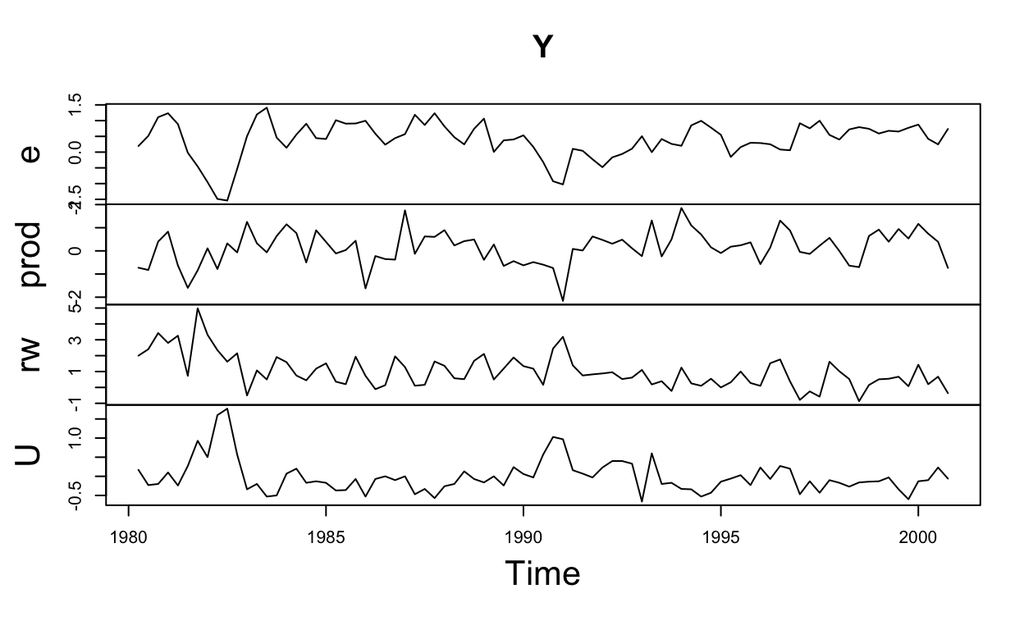

Figure 2: Benchmark dataset obtained by differencing the Canada time series from the vars package.

We illustrate the use of AIC and BIC for comparing VAR models with varying lag order $p=1,2,3$. OLS is included as a baseline, shrinkage parameters were selected automatically for the shrinkage methods, and for “fbayes”, “sbayes”, and “kcv”, the `dof` argument was set to `NULL`. Table 2 shows that, using the NS method, AIC attains its minimum at $p=3$, whereas BIC attains its minimum at $p=2$.

Table 2: Information criteria (AIC and BIC) for model comparison.

|  | AIC.p=1 | BIC.p=1 | AIC.p=2 | BIC.p=2 | AIC.p=3 | BIC.p=3 |
| --- | --- | --- | --- | --- | --- | --- |
| Ordinary least squares | 467.6 | 515.7 | 444.2 | 530.4 | 452.3 | 576.2 |
| Ridge regression | 465.8 | 504.6 | 442.9 | 509.3 | 445.3 | 525.9 |
| Nonparametric shrinkage | 454.5 | 478.9 | 426.6 | 471.4 | 422.5 | 485.4 |
| Full Bayes | 457.0 | 497.2 | 444.2 | 508.2 | 445.3 | 523.8 |
| Semi Bayes | 533.2 | 577.5 | 574.1 | 656.1 | 475.0 | 553.4 |
| K-fold CV | 495.7 | 538.2 | 466.2 | 525.4 | 472.9 | 538.1 |

The parameters estimated by the NS method with $p=2$ can be further analyzed using the class methods and functions listed in Table 1. For example, a test for serially correlated errors and an ARCH test can be performed as follows:

```r
fitted_Canada <- VARshrink(Y, p = 2, type = "none", method = "ns")
serial.test(fitted_Canada)
```

```
    Portmanteau Test (asymptotic)

data:  Residuals of VAR object fitted_Canada
Chi-squared = 176.31, df = 228, p-value = 0.9953
```

```r
arch.test(fitted_Canada)
```

```
    ARCH (multivariate)

data:  Residuals of VAR object fitted_Canada
Chi-squared = 508.04, df = 500, p-value = 0.3921
```

We can inspect the summary results to assess the statistical significance of each covariate affecting the unemployment rate through the model coefficients:

```r
summary_Canada <- summary(fitted_Canada)
print(summary_Canada$varresult[["U"]])
```

```
Call:
VARshrink(y = Y, p = 2, type = "none", method = "ns")

Residuals:
     Min       1Q   Median       3Q      Max
-0.84400 -0.16754 -0.00281  0.16971  0.72526

Coefficients:
        Estimate Std. Error t value Pr(>|t|)
e.l1    -0.36506    0.03356 -10.877  < 2e-16 ***
prod.l1 -0.13332    0.03502  -3.807 0.000283 ***
rw.l1    0.03840    0.02940   1.306 0.195426
U.l1     0.07101    0.03193   2.224 0.029098 *
e.l2     0.01561    0.03265   0.478 0.633932
prod.l2 -0.04137    0.03533  -1.171 0.245312
rw.l2    0.09894    0.02930   3.377 0.001157 **
U.l2    -0.11933    0.03161  -3.775 0.000314 ***
---
Signif. codes:  0 '***' 0.001 '**' 0.01 '*' 0.05 '.' 0.1 ' ' 1

Residual standard error: 0.2937 on 76.32037 degrees of freedom
Multiple R-squared:  0.5625,    Adjusted R-squared:  0.5414
F-statistic: 26.67 on 3.679632 and 76.32037 DF,  p-value: 2.873e-13
```

It is worthwhile to examine the correlations among the noise variables to evaluate concurrent relationships between the time series variables within the residuals:

```r
print(round(summary_Canada$corres, 3))
```

```
          e   prod     rw      U
e     1.000 -0.070 -0.039 -0.687
prod -0.070  1.000  0.086  0.018
rw   -0.039  0.086  1.000  0.207
U    -0.687  0.018  0.207  1.000
```

Time series forecasting can be performed, as illustrated in Figure 3.

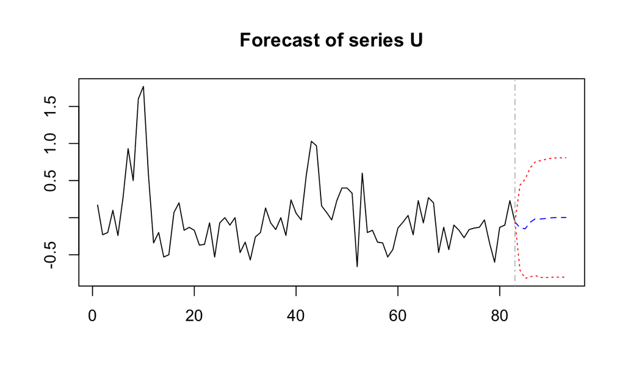

Figure 3: 10-step-ahead forecast of the differenced Canada time series using the VAR model estimated via the NS method with lag order $p=2$.

```r
plot(predict(fitted_Canada), names = "U")
```

Impulse responses can be computed from the same fitted object.

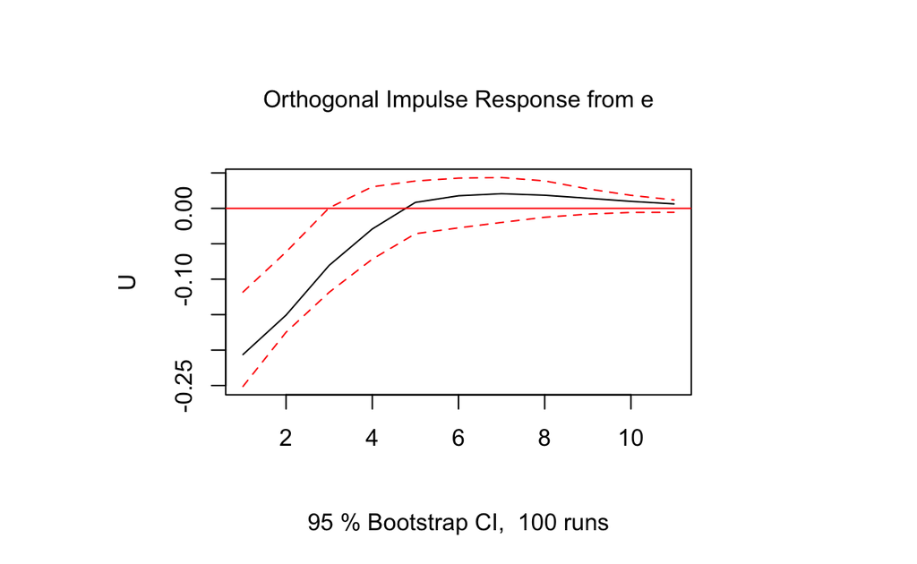

### 4.2 Comparative simulation

We generated multivariate time series data of length $T = 20, 40, 80, 160$ from $K = 20$ dimensional VAR models of order $p = 1$. Note that for $T = 20$, the sample size $N = T - p = 19$ is smaller than the dimensionality $K = 20$. The VAR coefficient matrix $\mathbf{A}_1$ was specified with diagonal entries of 0.6 and zeros elsewhere, except for $K$ entries randomly selected from the lower triangular part of the matrix. The nonzero off-diagonal entries were drawn uniformly at random from the intervals $[-1, -0.2]$ and $[0.2, 1]$. Since the coefficient matrix is lower triangular, the diagonal entries determine its eigenvalues, which lead to weak stationarity (Hamilton 1994; Tsay 2005). The noise $\boldsymbol\epsilon_t$ was randomly sampled from the multivariate normal distribution whose covariance matrix has diagonal entries of 1 and off-diagonal entries of 0.5. The experiments were repeated 50 times. We compared the four shrinkage methods and, when $T-p>K$, the OLS baseline. The sum of squared errors (SSEs) of the estimated VAR coefficients was used as a measure of parameter estimation accuracy. The summary of the coefficient SSEs is shown in Figure 4. The figure shows that the full Bayesian and semiparametric Bayesian methods produced accurate estimates with low SSEs, particularly for larger values of $T$, as they correctly incorporated correlations among the noise variables.

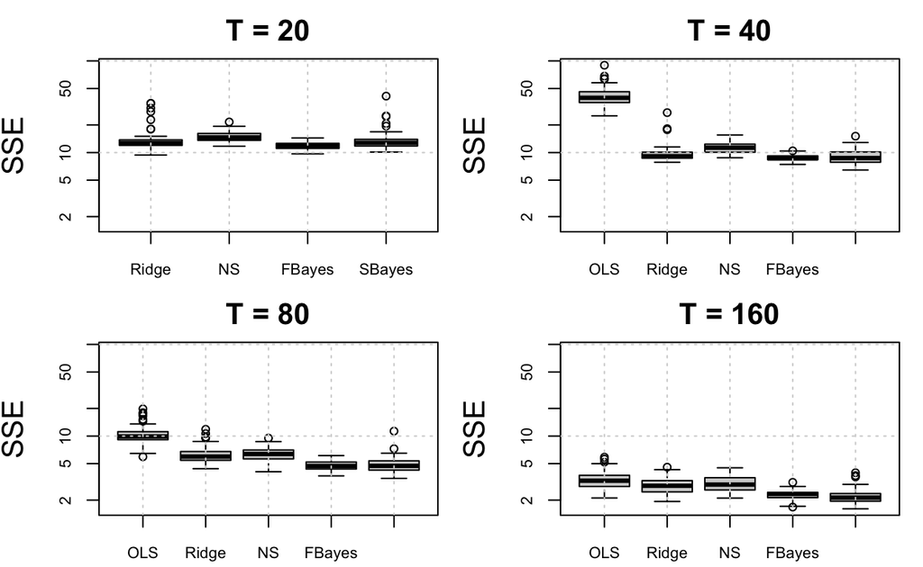

Figure 4: Comparison of mean SSEs across the four shrinkage methods and the OLS.

Figure 5 presents the out-of-sample forecasting performance of the shrinkage methods and the OLS baseline when estimable. Figure 6 presents the computational costs of the same methods as a function of the sample size. The full Bayesian method required the largest computational cost, indicating that computationally efficient alternative methods are needed for high-dimensional time series analysis.

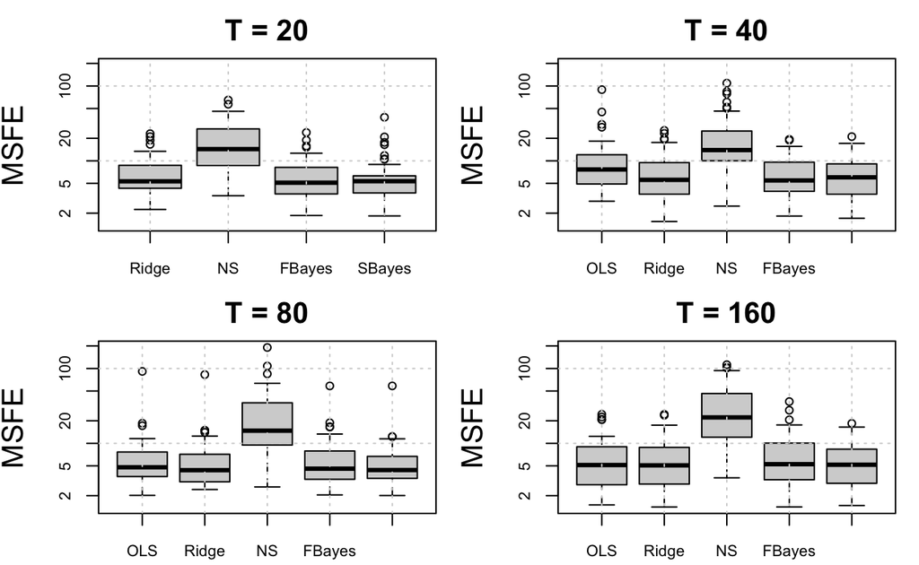

Figure 5: Comparison of 10-step out-of-sample MSFEs across the four shrinkage methods and the OLS baseline when estimable.

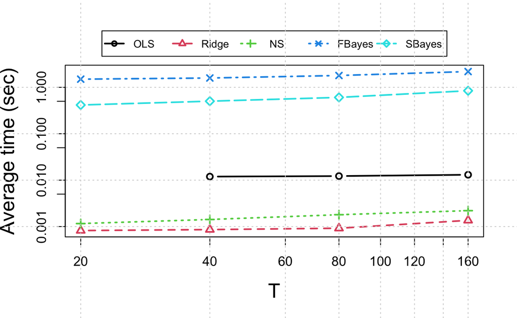

Figure 6: Comparison of computational costs across the four shrinkage methods and the OLS baseline when estimable as sample size increases.

To assess scalability with respect to the number of VAR coefficients, we also varied the dimension $K$ while holding $T=160$ and $p=1$ fixed. The number of autoregressive coefficients is $K^2p$. As shown in Figure 7, computational costs increase much more rapidly with the number of VAR coefficients than with the sample size.

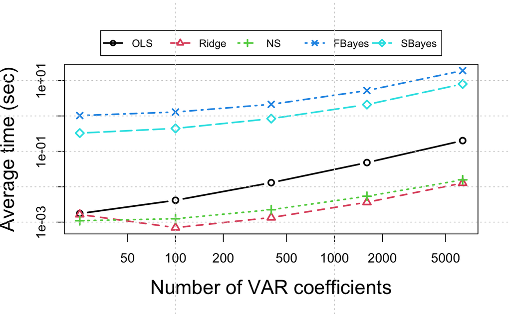

Figure 7: Comparison of computational costs across the four shrinkage methods and the OLS baseline as the number of VAR coefficients increases.

## 5 Discussion

The **R** ecosystem for multivariate time series has become increasingly specialized, as reflected in the CRAN Time Series Task View (Hyndman and Killick 2026). Packages such as vars and MTS provide established tools for VAR estimation, forecasting, and post-estimation analysis. Other packages focus on modern extensions: BigVAR and bigtime emphasize penalized estimation for large multivariate systems (Wilms et al. 2023; Nicholson et al. 2026), while BVAR, bayesianVARs, bvarsv, and bvartools support Bayesian workflows involving hierarchical prior selection, MCMC estimation, and stochastic volatility (Primiceri 2005; Giannone et al. 2015; Krueger 2015; Kuschnig and Vashold 2021; Mohr 2024; Gruber et al. 2026). For structural Bayesian VARs, bsvarSIGNs provides tools for sign, zero, and narrative restrictions (Wang and Woźniak 2025).

VARshrink is designed to complement these packages by bringing an OLS baseline and several shrinkage estimators into a common interface compatible with the widely used vars workflow. It currently includes multivariate ridge regression (Hoerl and Kennard 1970; Golub et al. 1979), a Stein-type nonparametric shrinkage method (Opgen-Rhein and Strimmer 2007), fully Bayesian methods with natural conjugate and non-conjugate priors (Ni and Sun 2005), and semiparametric Bayesian methods (Lee et al. 2016). This design allows users to compare OLS and alternative shrinkage estimators while retaining familiar tools for coefficient extraction, fitted values, residuals, forecasting, impulse responses, forecast error variance decompositions, diagnostic tests, and visualization.

The package is intended for applied researchers, students, and analysts who use the vars workflow but need more stable estimation than ordinary least squares can provide. Such settings arise when the number of variables is large relative to the number of observations, as in macroeconomic forecasting, financial systems, gene regulatory network analysis, and dynamic brain connectivity analysis (Harrison et al. 2003; Opgen-Rhein and Strimmer 2007; Bańbura et al. 2010). In these applications, shrinkage is useful not only for forecasting but also for stabilizing coefficient estimates used to study dynamic relationships, partial correlation structures, impulse responses, and forecast error variance decompositions.

The structural analysis tools in VARshrink come from this interoperability with vars. Because `varshrinkest` objects inherit from `varest`, users can apply familiar post-estimation tools from vars. For impulse responses, uncertainty calculation is estimator-specific: bootstrap re-estimation can be costly for shrinkage estimators, whereas stored MCMC draws can be used by `irf()` to form Bayesian credible intervals when the full Bayesian method is fitted with `store_mcmc = TRUE`. Users whose main goal is advanced structural identification, stochastic volatility, or sign, zero, and narrative restrictions may therefore prefer packages designed specifically for those purposes.

Several limitations remain. VARshrink does not yet implement the full range of modern Bayesian shrinkage priors, such as Minnesota-type, global-local, or hierarchical priors used in macroeconomic forecasting (Doan et al. 1984; Litterman 1986; Giannone et al. 2015; Kastner and Huber 2017). It also inherits structural identification from vars rather than developing a separate structural VAR framework. Finally, fully Bayesian estimation provides richer posterior information but is more computationally expensive than ridge or nonparametric shrinkage, especially as the number of variables grows. These limitations define the current scope of the package and suggest future extensions, including additional prior structures, structured penalties, and closer integration with modern structural VAR workflows.

## 6 Conclusions

Shrinkage methods are useful for VAR models when the number of parameters is large relative to the sample size. The **R** package VARshrink provides an OLS baseline and ridge, nonparametric, fully Bayesian, and semiparametric shrinkage estimators through a unified interface connected to the familiar vars class system. This allows users to compare OLS with shrinkage methods and then apply standard VAR tools for forecasting, visualization, diagnostics, impulse responses, and forecast error variance decompositions.

VARshrink complements specialized software for penalized forecasting, Bayesian prior selection, stochastic volatility, and structural identification. Its main role is to provide a common workflow for stable VAR coefficient estimation in high-dimensional settings. Future development can extend this framework with additional prior structures, structured penalties, and richer structural analysis tools while preserving compatibility with established VAR workflows in **R**.

## Computational details

The results in this manuscript were obtained using **R** 4.5.3 and VARshrink 0.5.0 on a MacBook running macOS 26.3.1, equipped with an Apple M4 Pro CPU and 24GB of memory.

## Reproduction code

varshrink-rjournal.R: R code to reproduce all the results in the manuscript.

## Acknowledgements

This work was supported by the National Research Foundation of Korea (NRF) grants funded by the Ministry of Science and ICT (MSIT) (RS-2024-00336424, RS-2024-00358572) and the Ministry of Education (MOE) (RS-2025-25415913) of the Republic of Korea. N. Lee was supported by the Regional Innovation System & Education (RISE) program through the Gangwon RISE Center funded by the MOE and the Gangwon State (G.S.), Republic of Korea (2026-RISE-10-002).

## Conflict of interest

The authors have no competing interests to declare that are relevant to the content of this article.

## Data availability

The Canada dataset was deposited by other researchers and is available in the **R** package vars at the CRAN repository, https://CRAN.R-project.org/package=vars.

### 6.1 Supplementary materials

Supplementary materials are available in addition to this article. It can be downloaded at RJ-2026-042.zip

### 6.2 CRAN packages used

vars, BigVAR, bigtime, bvartools, bayesianVARs, bvarsv, BVAR, bsvarSIGNs, corpcor, MASS, VARshrink, MTS

### 6.3 CRAN Task Views implied by cited packages

Bayesian, Distributions, Econometrics, Environmetrics, Finance, MixedModels, NumericalMathematics, Psychometrics, Robust, TeachingStatistics, TimeSeries

M. Bańbura, D. Giannone and L. Reichlin. Large Bayesian vector auto regressions. *Journal of Applied Econometrics*, 25(1): 71–92, 2010. DOI 10.1002/jae.1137.

L. Beltrachini, N. von Ellenrieder and C. H. Muravchik. Shrinkage approach for spatiotemporal EEG covariance matrix estimation. *IEEE Transactions on Signal Processing*, 61(7): 1797–1808, 2013. DOI 10.1109/TSP.2013.2238532.

H. Böhm and R. von Sachs. Shrinkage estimation in the frequency domain of multivariate time series. *Journal of Multivariate Analysis*, 100(5): 913–935, 2009. DOI 10.1016/j.jmva.2008.09.009.

T. Doan, R. Litterman and C. Sims. Forecasting and conditional projection using realistic prior distributions. *Econometric Reviews*, 3(1): 1–100, 1984. DOI 10.1080/07474938408800053.

T. Eltoft, T. Kim and T.-W. Lee. On the multivariate laplace distribution. *IEEE Signal Processing Letters*, 13(5): 300–303, 2006. DOI 10.1109/LSP.2006.870353.

M. Fiecas and H. Ombao. The generalized shrinkage estimator for the analysis of functional connectivity of brain signals. *The Annals of Applied Statistics*, 5(2A): 1102–1125, 2011. DOI 10.1214/10-AOAS396.

J. Friedman, T. Hastie, R. Tibshirani, N. Simon, B. Narasimhan and J. Qian. Glmnet: Lasso and elastic-net regularized generalized linear models. 2018. Available at https://cran.r-project.org/web/packages/glmnet.

D. Giannone, M. Lenza and G. E. Primiceri. Prior selection for vector autoregressions. *The Review of Economics and Statistics*, 97(2): 436–451, 2015. DOI 10.1162/REST_a_00483.

G. H. Golub, M. Heath and G. Wahba. Generalized cross-validation as a method for choosing a good ridge parameter. *Technometrics*, 21(2): 215–223, 1979. DOI 10.1080/00401706.1979.10489751.

L. Gruber, S. Haan and G. Kastner. bayesianVARs: MCMC estimation of Bayesian vector autoregressions. 2026. Available at https://cran.r-project.org/package=bayesianVARs.

J. D. Hamilton. *Time series analysis.* Princeton: Princeton University Press, 1994.

L. Harrison, W. D. Penny and K. Friston. Multivariate autoregressive modeling of fMRI time series. *NeuroImage*, 19: 1477–1491, 2003.

A. E. Hoerl and R. W. Kennard. Ridge regression: Biased estimation for nonorthogonal problems. *Technometrics*, 12(1): 55–67, 1970. DOI 10.1080/00401706.1970.10488634.

R. J. Hyndman and R. Killick. CRAN Task View: Time Series Analysis. 2026. URL https://CRAN.R-project.org/view=TimeSeries.

G. Kastner and F. Huber. Sparse Bayesian vector autoregressions in huge dimensions. 2017. URL https://arxiv.org/abs/1704.03239.

G. Koop and D. Korobilis. Bayesian multivariate time series methods for empirical macroeconomics. *Foundations and Trends in Econometrics*, 3(4): 267–358, 2010. DOI 10.1561/0800000013.

F. Krueger. Bvarsv: Bayesian analysis of a vector autoregressive model with stochastic volatility and time-varying parameters. 2015. Available at https://cran.r-project.org/web/packages/bvarsv.

N. Kuschnig and L. Vashold. BVAR: Bayesian vector autoregressions with hierarchical prior selection in R. *Journal of Statistical Software*, 100(14): 1–27, 2021. DOI 10.18637/jss.v100.i14.

O. Ledoit and M. Wolf. A well-conditioned estimator for large-dimensional covariance matrices. *Journal of Multivariate Analysis*, 88(2): 365–411, 2004. DOI 10.1016/S0047-259X(03)00096-4.

N. Lee, H. Choi and S.-H. Kim. Bayes shrinkage estimation for high-dimensional VAR models with scale mixture of normal distributions for noise. *Computationl Statistics & Data Analysis*, 101: 250–276, 2016. DOI 10.1016/j.csda.2016.03.007.

R. B. Litterman. Forecasting with Bayesian vector autoregressions: Five years of experience. *Journal of Business & Economic Statistics*, 4(1): 25–38, 1986. DOI 10.2307/1391384.

F. X. Mohr. bvartools: Bayesian inference of vector autoregressive and error correction models. 2024. Available at https://cran.r-project.org/package=bvartools.

S. Moritz and E. Cule. Ridge: Ridge regression with automatic selection of the penalty parameter. 2018. Available at https://cran.r-project.org/web/packages/ridge.

S. Ni and D. Sun. Bayesian estimates for vector autoregressive models. *Journal of Business & Economic Statistics*, 23(1): 105–117, 2005. DOI 10.1198/073500104000000622.

W. Nicholson, D. Matteson and J. Bien. BigVAR: Dimension reduction methods for multivariate time series. 2026. Available at https://cran.r-project.org/package=BigVAR.

R. Opgen-Rhein and K. Strimmer. Learning causal networks from systems biology time course data: An effective model selection procedure for the vector autoregressive process. *BMC Bioinformatics*, 8(2): S3, 2007. DOI 10.1186/1471-2105-8-S2-S3.

B. Pfaff and M. Stigler. vars: VAR modelling. 2018. Available at https://cran.r-project.org/web/packages/vars.

G. E. Primiceri. Time varying structural vector autoregressions and monetary policy. *The Review of Economic Studies*, 72(3): 821–852, 2005. DOI 10.1111/j.1467-937X.2005.00353.x.

B. Ripley, B. Venables, D. M. Bates, K. Hornik, A. Gebhardt and D. Firth. MASS: Support functions and datasets for venables and ripley’s MASS. 2018. Available at https://cran.r-project.org/web/packages/MASS.

J. Schäfer, R. Opgen-Rhein, V. Zuber, M. Ahdesmäki, A. P. D. Silva and K. Strimmer. Corpcor: Efficient estimation of covariance and (partial) correlation. 2017. Available at http://CRAN.R-project.org/package=corpcor.

J. Schäfer and K. Strimmer. A shrinkage approach to large-scale covariance matrix estimation and implications for functional genomics. *Statistical Applications in Genetics and Molecular Biology*, 4(1): 32, 2005. DOI 10.2202/1544-6115.1175.

D. Sun and S. Ni. Bayesian analysis of vector-autoregressive models with noninformative priors. *Journal of Statistical Planning and Inference*, 121(2): 291–309, 2004. DOI 10.1016/S0378-3758(03)00116-2.

R. S. Tsay. *Analysis of financial time series.* 2nd ed Hoboken, NJ: John Wiley & Sons, 2005.

R. S. Tsay and D. Wood. MTS: All-purpose toolkit for analyzing multivariate time series (MTS) and estimating multivariate volatility models. 2018. Available at https://cran.r-project.org/web/packages/MTS.

X. Wang and T. Woźniak. bsvarSIGNs: Bayesian SVARs with sign, zero, and narrative restrictions. 2025. Available at https://cran.r-project.org/package=bsvarSIGNs.

M. West. Outlier models and prior distributions in Bayesian linear regression. *Journal of the Royal Statistical Society. Series B (Methodological)*, 46(3): 431–439, 1984.

I. Wilms, D. S. Matteson, J. Bien, S. Basu, W. Nicholson and E. Wegner. bigtime: Sparse estimation of large time series models. 2023. Available at https://cran.r-project.org/package=bigtime.